# MUSA 507 Midterm Project – San Francisco Hedonic Home Price Prediction

## 2.3.1 Summary Statistics

Following is the table of summary statistics using the Stargazer package.

```r
stargazer(as.data.frame(student2), type="text", title = "Summary Statistics")
```

```
##
## Summary Statistics
## =============================================================================================================================
## Statistic                              N        Mean       St. Dev.        Min        Pctl(25)      Pctl(75)         Max
## -----------------------------------------------------------------------------------------------------------------------------
## X                                    10,078 5,998,962.000  8,956.204  5,980,569.000 5,992,443.000 6,005,293.000 6,020,464.000
## Y                                    10,078 2,100,286.000  8,463.156  2,086,052.000 2,094,039.000 2,105,302.000 2,121,818.000
## long                                 10,078    37.747        0.023       37.708        37.730        37.761        37.806
## lat                                  10,078   -122.446       0.031      -122.511      -122.469      -122.425      -122.371
## SalePrice                            10,078 1,064,620.000 735,206.300       0         642,602.5    1,327,752.0    4,750,003
## LotArea                              10,078  247,080.900  136,698.800       0          187,500       300,000      1,890,500
## PropArea                             10,078   1,647.934     774.378        187          1,159         1,978        24,308
## BuiltYear                            10,078    56.825       26.155          1            36            71            139
## Stories                              10,078     1.346        0.676          0             1             2            10
## Units                                10,078     1.000        0.000          1             1             1             1
## Rooms                                10,078     6.217        2.125          0             5             7            26
## Beds                                 10,078     1.702        1.700          0             0             3            10
## Baths                                10,078     1.801        0.961          0             1             2             8
## holdOut                              10,078     0.069        0.254          0             0             0             1
## Graduate/Professional Degree         10,078     0.191        0.104        0.030         0.090         0.280         0.420
## Average Household Size               10,078     2.724        0.620        1.600         2.200         3.400         3.600
## Managerial Professional              10,078     0.274        0.123        0.032         0.159         0.374         0.532
## Fair Market Rent                     10,078   2,550.188     542.181       1,800         2,010         3,000         4,330
## No Bedroom                           10,078     0.048        0.050        0.010         0.020         0.060         0.630
## Foreign Born                         10,078     0.360        0.118        0.140         0.280         0.430         0.700
## Employment Rate                      10,078     0.550        0.076        0.419         0.508         0.583         0.739
## Some College/Associate Degree        10,078     0.223        0.044        0.100         0.200         0.250         0.300
## College Degree                       10,078     0.300        0.086        0.160         0.210         0.350         0.520
## Asian                                10,078     0.350        0.171        0.080         0.160         0.510         0.800
## 20 Units or more                     10,078     0.090        0.144        0.000         0.020         0.080         0.940
## Households with Children, % of Total 10,078     0.252        0.092        0.060         0.180         0.300         0.400
## Owner occupied                       10,078     0.514        0.173        0.030         0.400         0.620         0.790
## Black/African American               10,078     0.058        0.076        0.000         0.010         0.060         0.310
## Vacant Units                         10,078     0.061        0.021        0.020         0.050         0.070         0.220
```

[output cut: 17 more lines]

## 2.3.2 correlation matrix

The correlation matrix of selected variables can help us to find the correlation between two variables.

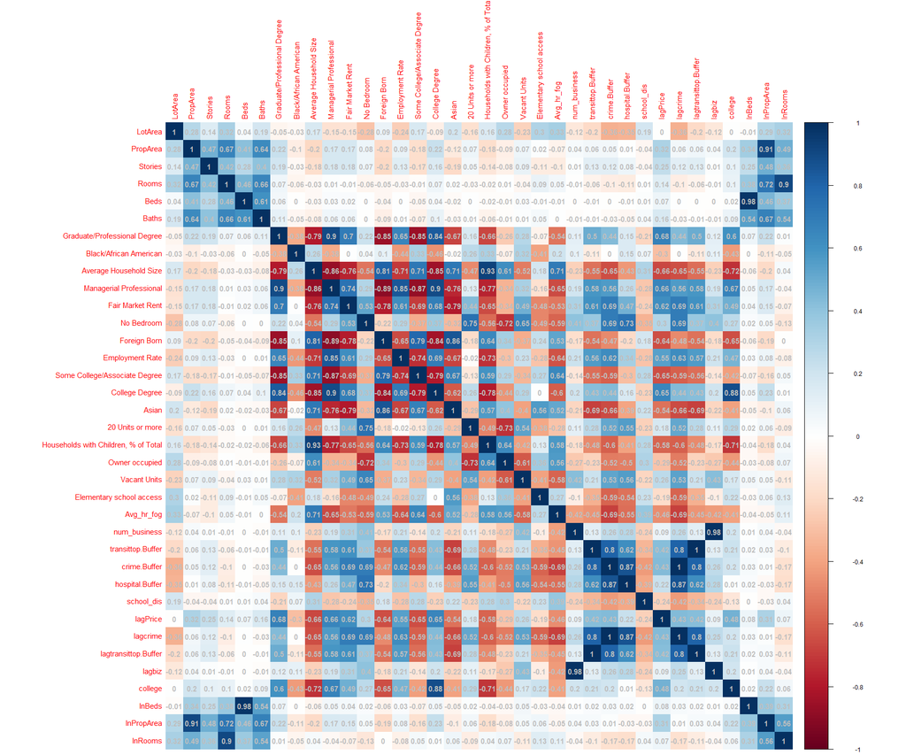

1

## 2.3.3 Correlation Scatterplots

The scatterplots of home price correlated with 4 different variable. We select 4 interesting variables to make scatterlots of home price correlation.

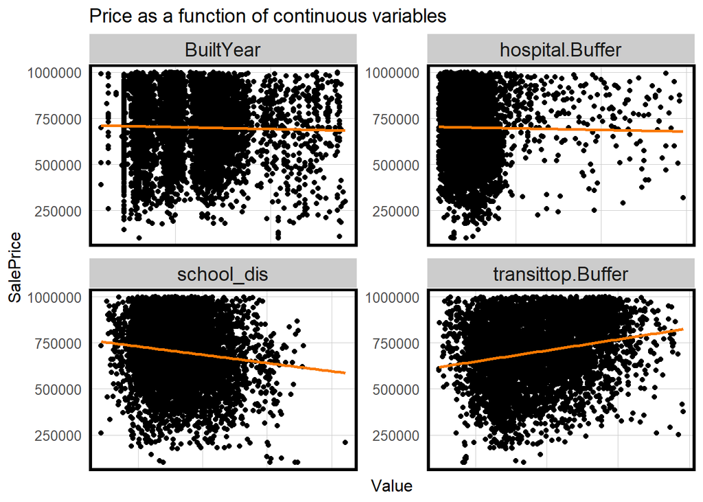

```r
as.data.frame(student2) %>%
  dplyr::select(SalePrice, transittop.Buffer, school_dis, hospital.Buffer,BuiltYear) %>%
  filter(SalePrice <= 1000000 & SalePrice > 0,BuiltYear > 10) %>%
  gather(Variable, Value, -SalePrice) %>%
   ggplot(aes(Value, SalePrice)) +
     geom_point() +
     geom_smooth(method = "lm", se=F, colour = "#FA7800") +
     facet_wrap(~Variable, ncol = 2, scales = "free") +
     labs(title = "Price as a function of continuous variables") +
     theme(axis.text.x = element_blank()) +
     plotTheme()
```

## 2.3.4 Map of sale price

From that the dependent variable SalePrice can be plot on the map.Here is the Distribution Map of the Sales Price. From this map, it can be seen that high value houses located in the center and the north of the San Francisco.The west and the south-west houses have a lower value. The south-east seems has the lowest value.

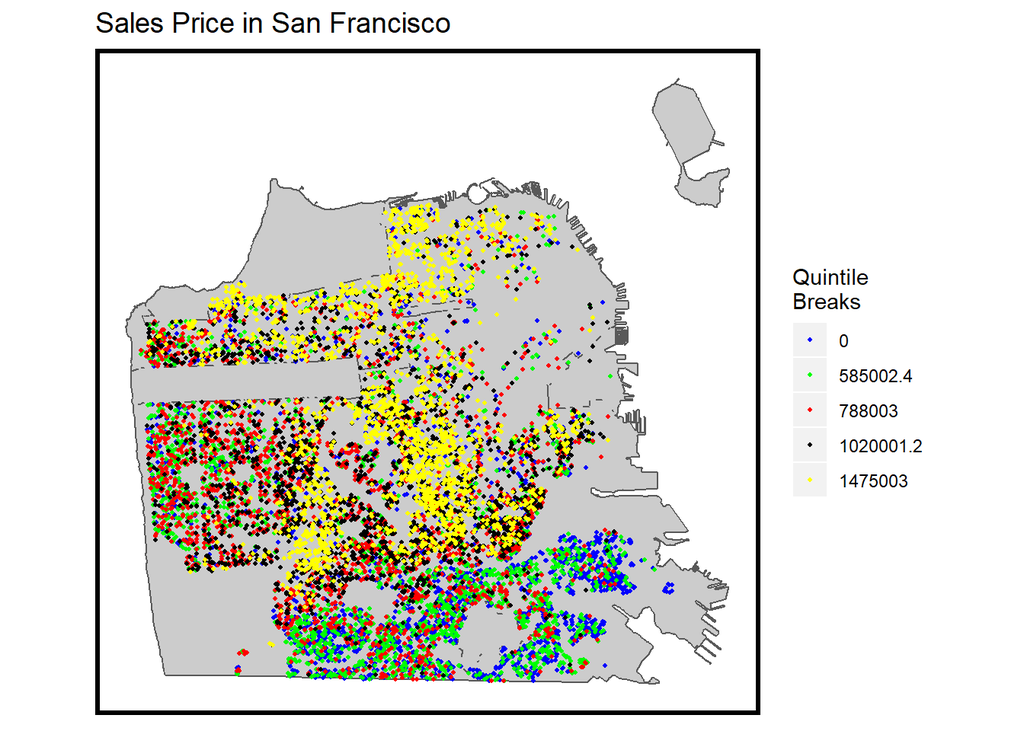

```r
ggplot() +
  geom_sf(data=st_union(baseMap),fill='grey80') +
  geom_sf(data = student, aes(color = q5(SalePrice)), show.legend = "point", size = .75) +
  scale_colour_manual(values = palette5,
                      labels=qBr(student,"SalePrice"),
                      name="Quintile\nBreaks") +
  labs(title="Sales Price in San Francisco") +
  mapTheme()
```